Artificial Intelligence - University of Bucharest

# **Bayesian Learning for Neural Networks**

## Probabilistic Programming (Project 2)

**Sotir Anca-Nicoleta, group 407**

In this project I will present the implementation of **Bayesian Neural Networks** in **Pyro** for classification tasks:

- a *linearly separable binary classification* problem - the 'sanity check'
- a *non-linearly separable binary classification* problem
- a *multinomial classification* problem

The datasets used for these three problems are all artificial, generated either by applying some formula (first case) or by using the `sklearn.datasets` module.

In all cases where a bayesian network is implemented, a corresponding classic neural network was also implemented to compare their results.

# Setup

Firstly, we need to install pyro for this notebook and import all the necessary packages.

```python
%%capture
!pip install pyro-ppl
```

```python
import numpy as np
import matplotlib.pyplot as plt
from matplotlib import markers

import pyro
import pyro.distributions as dist
from pyro.distributions import Normal, Categorical
from pyro.infer import SVI, Trace_ELBO, Predictive
from pyro.infer.autoguide import AutoDiagonalNormal
from pyro.optim import Adam
from pyro.nn import PyroModule, PyroSample

import torch
import torch.nn as nn
import torch.nn.functional as F
import torch.optim as optim

from sklearn.datasets import make_moons, make_classification # methods to generate data for the 2nd and 3rd problems
```

# Utility functions

These functions are used for plotting.

```python
def multiple_marker_style_scatter(x, y, marker_style, ax = None, **kw):
    '''
    This allows to use multiple marker styles (for example, when plotting classification results,
    each class can have a different marker style)
    '''
    if ax is not None:
        scatter_plot = ax.scatter(x, y, **kw)
    else:
        scatter_plot = plt.scatter(x, y, **kw)
    paths = []
    for m in marker_style:
        marker_obj = markers.MarkerStyle(m)
        path = marker_obj.get_path().transformed(marker_obj.get_transform())
        paths.append(path)
    scatter_plot.set_paths(paths)
    return scatter_plot
```

```python
def plot_decision_boundary(test_data, test_labels, network_type, model, guide = None, num_samples = 1000):
    '''
    This is useful after training a model, to see if it learned a good separation of the data.
    It works by creating all possible points in a certain 2D range and then predicting their labels.
    It also plots the test data and their correct labels.
    '''
    # firstly the range is considered to be determined by the test data min-max range on the xy-axis
    xmin = test_data[:,0].min().item()
    xmax = test_data[:,0].max().item()
    ymin = test_data[:,1].min().item()
    ymax = test_data[:,1].max().item()
    # then 100 equally distanced points are considered in that x-axis range and y-axis range respectively
    xs = np.linspace(xmin, xmax, 100)
    ys = np.linspace(ymin, ymax, 100)
    # the cartesian product of those coordinates is computed to find all points in that square
    comb = np.transpose([np.tile(xs, len(ys)), np.repeat(ys, len(xs))])
    comb = torch.from_numpy(comb).type(torch.float32)
    xs = comb[:,0]
    ys = comb[:,1]
    # obtaining results differs based on the neural network type ('bayesian' or 'classic')
    if network_type == 'bayesian':
        predictive = Predictive(model, guide = guide, num_samples = num_samples)
        data = predictive(comb)
        predictions = data.get('result').detach().numpy() # fetch the labels from the model
        predictions = np.asarray(np.round(np.mean(predictions, axis = 0)), dtype = 'int')
    if network_type == 'classic':
        with torch.no_grad(): # no need to compute gradients when testing
            output = model(comb)
        predictions = np.argmax(output, axis = 1)
    # plot the network's predictions
    label_colors = np.array(['purple', 'orange','royalblue','lightseagreen'])
    label_markers = np.array(['o', 'o','o','o'])
    plt.figure(figsize = (10, 10))
    plt.title('Neural Network Decision Boundary')
    multiple_marker_style_scatter(xs, ys, label_markers[predictions], color = label_colors[predictions], alpha = 0.1)
    multiple_marker_style_scatter(test_data[:, 0], test_data[:, 1], label_markers[test_labels], color = label_colors[test_labels])
    plt.show()
```

```python
def display_drive_image(img_path, figsize = (10, 10)):
    '''
    This is used for plotting an image found on my Google Drive.
    '''
    fig = plt.figure(figsize = figsize)
    plt.imshow(plt.imread(img_path))
    fig.patch.set_visible(False)
    plt.axis('off')
    plt.show()
```

# Sanity Check

This is the first classification problem. The dataset is generated by applying the formula given the following network architecture with fixed weights and no bias:

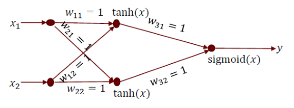

```python
display_drive_image('/content/drive/MyDrive/PP/Project2/images/sanity-check-network.PNG')
```

## Generate data

```python
def generate_data(samples_no):
  X = np.random.randn(samples_no, 2) # generating random 2D input values
  Y = np.tanh(X[:, 0] + X[:, 1])     # this is the value computed by a node on the hidden layer
  Y = 1 / (1 + np.exp(-(Y + Y)))     # applying sigmoid function
  Y = Y > 0.5                        # label 1 if sigmoid is greater than 0.5, else 0
  return X, Y.astype(int)            # return samples_no such points and their labels
```

```python
train_data, train_labels = generate_data(100)
test_data, test_labels = generate_data(100)
```

The generated data can be seen below. It is clearly visible that the points are linearly separable.

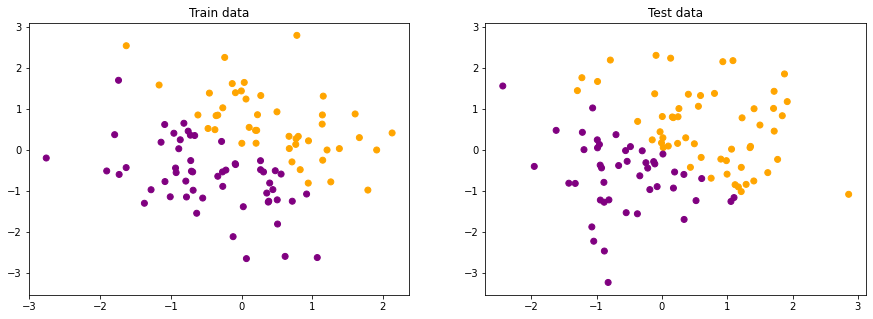

```python
label_colors = np.array(['purple', 'orange'])
label_markers = np.array(['o', 'o'])

fig, ax = plt.subplots(1, 2, figsize = (15, 5), sharey = True)
ax[0].set_title('Train data')
ax[0] = multiple_marker_style_scatter(train_data[:, 0], train_data[:, 1], label_markers[train_labels], ax =  ax[0],  color = label_colors[train_labels])
ax[1].set_title('Test data')
ax[1].yaxis.set_tick_params(which = 'both', labelleft = True)
ax[1] = multiple_marker_style_scatter(test_data[:, 0], test_data[:, 1], label_markers[test_labels], ax = ax[1], color = label_colors[test_labels])
plt.show()
```

```python
# create tensors from the initial numpy arrays containing the data

train_data = torch.from_numpy(np.asarray(train_data)).type(torch.float32)
train_labels = torch.from_numpy(np.asarray(train_labels, dtype = 'int'))

test_data = torch.from_numpy(np.asarray(test_data)).type(torch.float32)
test_labels = torch.from_numpy(np.asarray(test_labels, dtype = 'int'))
```

## The Bayesian Neural Network

To implement the Bayesian Network, a **prior over the network's parameters must be defined**. Then, during **inference**, good parameter values can be learned starting from it.

In *Bayesian Learning for Neural Networks*, by Radford M. Neal, I found the piece of information displayed below. Because of this, I decided to use as prior for the parameters of the Bayesian Networks implemented in this notebook a **Normal distribution of mean 0 and standard deviation 1** .

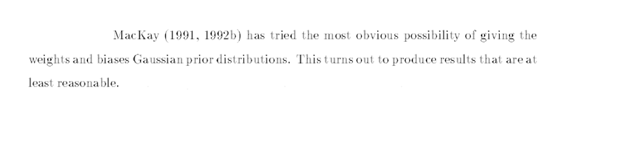

```python
display_drive_image('/content/drive/MyDrive/PP/Project2/images/params-prior-dist.PNG', figsize = (20, 20))
```

Next we need to define the bayesian neural network. It can be seen that instead of just using the `nn.Linear` layer from Pytorch (i.e. what we would use in a classic neural network), it is wrapped by a `PyroModule` and its weights are sampled from the prior distribution of `Normal(0, 1)`.

```python
class BNN(PyroModule):

    # define the initialization method which creates the network's layers
    def __init__(self, input_size, hidden_size, output_size):
        super().__init__()
        # the hidden fully connected layer
        self.fc1 = PyroModule[nn.Linear](input_size, hidden_size, bias = False)
        self.fc1.weight = PyroSample(dist.Normal(0., 1.).expand([hidden_size, input_size]).to_event(2))
        # the output layer
        self.out = PyroModule[nn.Linear](hidden_size, output_size, bias = False)
        self.out.weight = PyroSample(dist.Normal(0., 1.).expand([output_size, hidden_size]).to_event(2))

    # define the way of passing the input through the network
    def forward(self, x, y = None):
        x = self.fc1(x)
        x = torch.tanh(x)
        x = self.out(x)
        p1 = torch.sigmoid(x) # a value between 0 and 1 for each input entry
        # p1 is the probability of the input to produce a label of value 1

        # also deduce the probability of the input to produce a label of value 0
        # thus, p will be given to a Categorical distribution for the label
        p = torch.randn(x.shape[0], 2)
        for i in range(len(p1)):
            p[i][0] = 1 - p1[i]
            p[i][1] = p1[i]

        # using plate because data is given in batchez, not individual entries
        with pyro.plate("data", x.shape[0]):
            result = pyro.sample("result", dist.Categorical(p), obs = y) # note the obs is given for inference
            # the resulting labels are given by a Categorical distribution
            # for training, the labels will be given to this method and they will be marked as observed variable
        return result
```

```python
# create the bayesian network with the same architecture that was used to generate data
model = BNN(2, 2, 1)
# automatically create a guide for inference
guide = AutoDiagonalNormal(model)
# an Adam optimizer will be used
optim = Adam({"lr": 0.01})

# Stochastic Variational Inference in Pyro
svi = SVI(model, guide, optim, loss = Trace_ELBO())
# I chose the most commonly used loss, which is Trace_ELBO()
```

```python
pyro.clear_param_store()

num_iterations = 100
loss_history = [] # this will be used for plotting

for it in range(num_iterations):
  loss = svi.step(train_data, train_labels) # compute the loss on the training data
                                            # the labels are also passed because they are the observed variable
  total_epoch_loss_train = loss / len(train_data) # average entry loss
  if (it + 1) % 10 == 0: # print progress every few iterations
    print("Iteration ", str(it + 1).ljust(5), " Loss ", total_epoch_loss_train)
  loss_history.append(total_epoch_loss_train)
```

```
Iteration  10     Loss  0.7554164981842041
Iteration  20     Loss  0.7222826707363129
Iteration  30     Loss  0.5958922743797302
Iteration  40     Loss  0.5259351229667664
Iteration  50     Loss  0.5768481957912445
Iteration  60     Loss  0.4520971667766571
Iteration  70     Loss  0.46244505405426023
Iteration  80     Loss  0.4040131306648254
Iteration  90     Loss  0.3770783948898315
Iteration  100    Loss  0.3818127465248108
```

The inference process has ended and the Bayesian Network's loss curve can be visualized below:

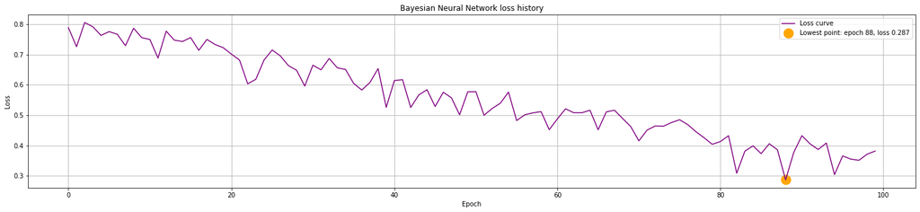

```python
plt.figure(figsize = (25, 5))
plt.plot(loss_history, c = 'purple', label = 'Loss curve')
plt.title('Bayesian Neural Network loss history')
plt.xlabel('Epoch')
plt.ylabel('Loss')
plt.grid(True, 'both')

lowest_epoch = np.argmin(loss_history)
plt.scatter(lowest_epoch, loss_history[lowest_epoch], c = 'orange', marker = 'o', label = f'Lowest point: epoch {lowest_epoch}, loss {round(loss_history[lowest_epoch], 3)}', linewidths = 10)

plt.legend()
plt.show()
```

We can now visualize the posterior distribution over the network's parameters. We can also sample the model and plot the posterior distribution.

```python
guide.requires_grad_(False)

for name, value in pyro.get_param_store().items():
    print(name, pyro.param(name), '\n')
```

```
AutoDiagonalNormal.loc Parameter containing:
tensor([ 1.2359,  1.0092, -0.8490, -1.1693,  1.0451, -1.1363])

AutoDiagonalNormal.scale tensor([0.2175, 0.2093, 0.2065, 0.2395, 0.1654, 0.1833])
```

```python
def sample_models(samples_no = 1000):
  return [guide(_, _) for _ in range(samples_no)]

model_samples = sample_models()
print('A model sample:\n')
for param in model_samples[0]:
  print(param, '\n', str(model_samples[0][param]), '\n')
```

```
A model sample:

fc1.weight
 tensor([[ 1.2006,  0.9571],
        [-0.4926, -0.9212]])

out.weight
 tensor([[ 1.0898, -1.1581]])
```

```python
# extract weight values from the sampled models to plot their histograms

w11 = []
w12 = []
w21 = []
w22 = []
w31 = []
w32 = []

for sample in model_samples:
  w11.append(sample['fc1.weight'][0][0].item())
  w12.append(sample['fc1.weight'][0][1].item())
  w21.append(sample['fc1.weight'][1][0].item())
  w22.append(sample['fc1.weight'][1][1].item())
  w31.append(sample['out.weight'][0][0].item())
  w32.append(sample['out.weight'][0][1].item())
```

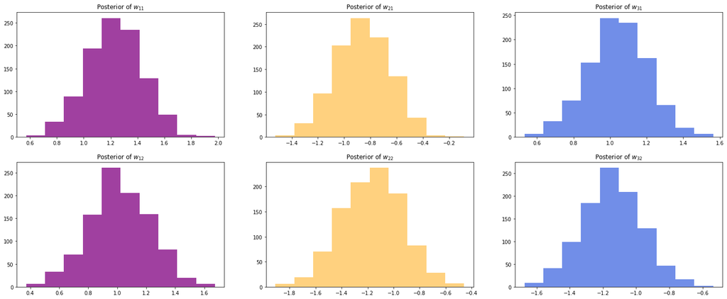

```python
fig, axs = plt.subplots(2, 3, figsize = (25, 10))
axs[0][0].hist(w11, color = 'purple', alpha = 0.75)
axs[0][0].set_title(r'Posterior of $w_{11}$')
axs[1][0].hist(w12, color = 'purple', alpha = 0.75)
axs[1][0].set_title(r'Posterior of $w_{12}$')
axs[0][1].hist(w21, color = 'orange', alpha = 0.5)
axs[0][1].set_title(r'Posterior of $w_{21}$')
axs[1][1].hist(w22, color = 'orange', alpha = 0.5)
axs[1][1].set_title(r'Posterior of $w_{22}$')
axs[0][2].hist(w31, color = 'royalblue', alpha = 0.75)
axs[0][2].set_title(r'Posterior of $w_{31}$')
axs[1][2].hist(w32, color = 'royalblue', alpha = 0.75)
axs[1][2].set_title(r'Posterior of $w_{32}$')
plt.show()
```

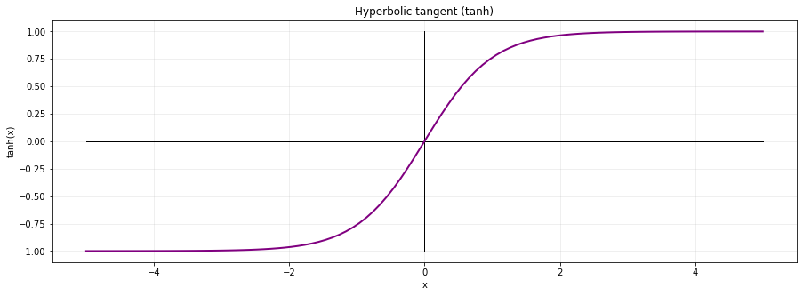

```python
x = torch.from_numpy(np.linspace(-5, 5, 100))
y = torch.tanh(x)
plt.figure(figsize = (15, 5))
plt.plot([0]*100, np.linspace(-1, 1, 100), color = 'black', linewidth = 1)
plt.plot(x, [0]*100, color = 'black', linewidth = 1)
plt.plot(x, y, color = 'purple', linewidth = 2, label = '')
plt.grid(True, 'both', alpha = 0.25)
plt.title('Hyperbolic tangent (tanh)')
plt.xlabel('x')
plt.ylabel('tanh(x)')
plt.show()
```

As it can be seen in the Hyperbolic tangent function's plot, $tanh(x) = -tanh(-x)$ (it is a symmetric - odd - function).

Data was generated in the following manner:

$y = sigmoid(tanh(x_1w_{11} + x_2w_{12}) \cdot w_{31} + tanh(x_1w_{21} + x_2w_{22}) \cdot w_{32})$

For weights fixed to 1, the equations becomes: $y = sigmoid(2 \cdot tanh(x_1 + x_2)) $

For weights fixed to -1, the equations becomes: $y = sigmoid(-2 \cdot tanh(-x_1 - x_2)) $

Because $tanh(x) = -tanh(-x)$ , we can say that $tanh(x_1 + x_2) = -tanh(-x_1 - x_2)$. Thus, we obtain the same result with parameters fixed to 1 and to -1.

```python
# sampling 1000 models and obtain final predictions on the test set
num_samples = 1000
predictive = Predictive(model, guide=guide, num_samples=num_samples)
data = predictive(test_data)
predictions = data.get('result').detach().numpy()
predictions = np.round(np.mean(predictions, axis = 0))
```

```python
# compute the accuracy
correct = 0
total = 0
for i in range(len(test_data)):
    total += 1
    correct += (predictions[i] == test_labels[i]).item()
```

```python
print("Accuracy: %d %%" % (100 * correct / total))
```

```
Accuracy: 100 %
```

[figure not shown]

```python
plot_decision_boundary(test_data, test_labels, 'bayesian', model, guide, 1000)
```

It can be seen that the model's parameters were inferred successfully, with a score of **100% accuracy on the test set**. The problem was not difficult at all for a neural network because it was linearly separable.

## The Classic Neural Network

Next will be implemented a Classic Neural Network corresponding to the Bayesian one implemented above. I tried to achieve the best results I could get with a similar architecture to compare their results accordingly.

It was also implemented in PyTorch.

```python
class NN(nn.Module):

    # initialize the networks layers
    #(note that no probabilistic programming wrapper was used in this one)
    def __init__(self, input_size, hidden_size, output_size):
        super(NN, self).__init__()
        self.fc1 = nn.Linear(input_size, hidden_size, bias = False)
        self.out = nn.Linear(hidden_size, output_size, bias = False)

    # no more random variables
    # only pass the imput through the layers and return a probability for each class
    def forward(self, x):
        x = self.fc1(x)
        x = torch.tanh(x)
        x = self.out(x)
        p1 = torch.sigmoid(x)
        p = torch.randn(x.shape[0], 2)
        for i in range(len(p1)):
            p[i][0] = 1 - p1[i]
            p[i][1] = p1[i]
        return p
```

```python
net = NN(2, 2, 1) # create a model with the same number of neurons as the bayesian one
```

```python
# adam optimizer again
optimizer = torch.optim.Adam(net.parameters(), lr=0.01)

# Negative Log Likelihood loss - used on the probabilities returned by the network
# the higher the probability, the lower the corresponding negative log likelihood
lossf = nn.NLLLoss()

epoch_no = 500
loss_history = []

for e in range(epoch_no):
    optimizer.zero_grad() # clear the gradient buffers
    output = net(train_data) # pass the training data (no labels are passed because no inference)
    loss = lossf(output, train_labels) # compute the loss on the results
    if (e + 1) % 25 == 0: # print progress every few epochs
      print("Epoch", str(e + 1).ljust(5), "Loss", loss.item())
    loss_history.append(loss)
    loss.backward() # backpropagate the loss
    optimizer.step() # make changes to the network's parameters
```

```
Epoch 25    Loss -0.5174986720085144
Epoch 50    Loss -0.584559977054596
Epoch 75    Loss -0.6755282878875732
Epoch 100   Loss -0.7702821493148804
Epoch 125   Loss -0.834327757358551
Epoch 150   Loss -0.8717864751815796
Epoch 175   Loss -0.8951107859611511
Epoch 200   Loss -0.9107096791267395
Epoch 225   Loss -0.9218204021453857
Epoch 250   Loss -0.9301292300224304
Epoch 275   Loss -0.9365811347961426
Epoch 300   Loss -0.9417416453361511
Epoch 325   Loss -0.9459697008132935
Epoch 350   Loss -0.9495026469230652
Epoch 375   Loss -0.9525042772293091
Epoch 400   Loss -0.9550904631614685
Epoch 425   Loss -0.9573453664779663
Epoch 450   Loss -0.9593322277069092
Epoch 475   Loss -0.9610990285873413
Epoch 500   Loss -0.9626825451850891
```

The classic network was trained and the loss history can be visualized below:

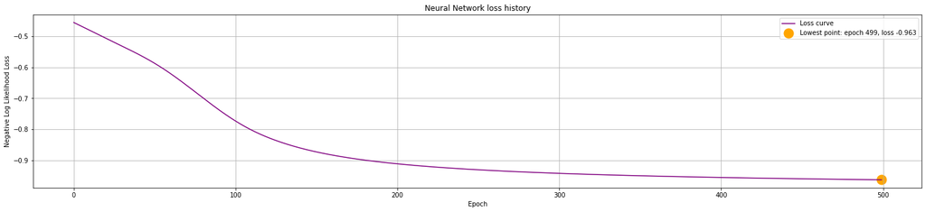

```python
plt.figure(figsize = (25, 5))
plt.plot(loss_history, c = 'purple', label = 'Loss curve')
plt.title('Neural Network loss history')
plt.xlabel('Epoch')
plt.ylabel('Negative Log Likelihood Loss')
plt.grid(True, 'both')
lowest_epoch = np.argmin(loss_history)
plt.scatter(lowest_epoch, loss_history[lowest_epoch].detach().numpy(),
            c = 'orange', marker = 'o', label = f'Lowest point: epoch {lowest_epoch}, loss {round(loss_history[lowest_epoch].item(), 3)}', linewidths = 10)
plt.legend()
plt.show()
```

```python
# the values of the neural network's weights
for param in net.parameters():
  print(str(param), '\n')
```

```
Parameter containing:
tensor([[ 2.1751,  2.1091],
        [-1.8454, -1.9103]], requires_grad=True)

Parameter containing:
tensor([[ 3.1818, -2.8676]], requires_grad=True)
```

It can be observed that the network's weights are as follows:

$w_{11} \approx w_{12} \approx 2$

$w_{31} \approx 3$

$w_{21} \approx w_{22} \approx -2$

$w_{31} \approx -3$

Through similar computations as before, it could be seen that the result stays the same as for the Bayesian network because, even though the weights are not 1 or -1, the result of the sigmoid is the same.

Intuitively, a negative number multiplied by a positive number is even smaller; a positive number multiplied by a positive number is even greater. That is why the network learned such weights as 2, -2, 3, -3 as opposed to just -1, 1, which **can be seen as a degree of certainty** (larger negative values will result in smaller probability given by sigmoid, while larger positive values will result in greater probability given by sigmoid).

```python
# obtain output on test set
with torch.no_grad():
  test_output = net(test_data)
```

```python
# get predictions (output is represented by probabilities)
# argmax gives the class index of the biggest probability
predictions = np.argmax(test_output, axis = 1)
```

```python
# compute accuracy
correct = 0
total = 0
for i in range(len(test_data)):
    total += 1
    correct += (predictions[i] == test_labels[i]).item()
```

```python
print("Accuracy: %d %%" % (100 * correct / total))
```

```
Accuracy: 100 %
```

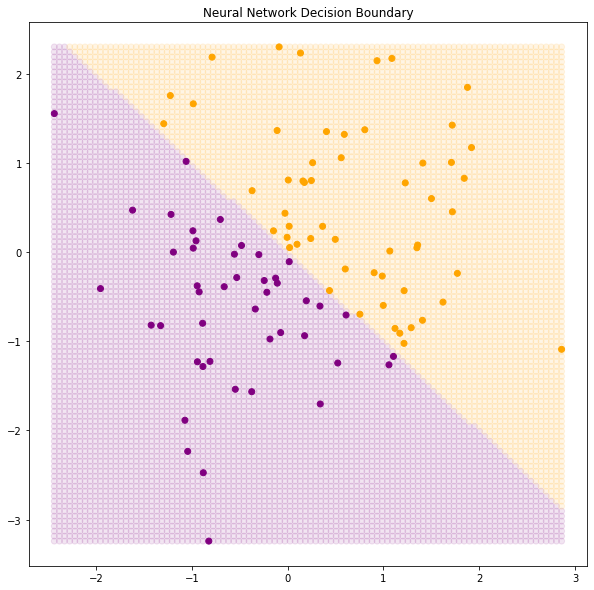

```python
plot_decision_boundary(test_data, test_labels, 'classic', net)
```

Finally, it can be seen that, for a classic neural network with one hidden layer, finding the decision boundary for a linearly separable problem is a very easy task. Thus, not surprisingly, **the accuracy score on the testing set is 100%**.

# Binary Classification

For further experimentation with Bayesian Neural Networks, a more complex binary classification problem is considered. The dataset which is used for this task is a toy dataset generated with the help of the `sklearn.dataset` package and it is called **Two Moons**.

## Generate data

Firstly, the training and testing sets must be generated. They can also be visualized below:

```python
# generate the train and test data and corresponding labels
train_data, train_labels = make_moons(noise = 0.2, random_state = 0, n_samples = 750)
test_data, test_labels = make_moons(noise = 0.2, random_state = 0, n_samples = 250)
```

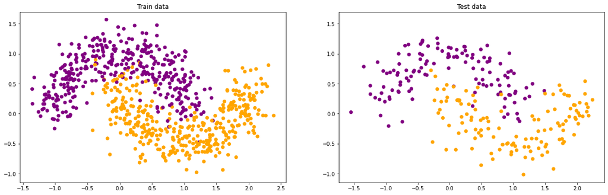

```python
label_colors = np.array(['purple', 'orange'])
label_markers = np.array(['o', 'o'])

fig, ax = plt.subplots(1, 2, figsize = (20, 6), sharey = True)
ax[0].set_title('Train data')
ax[0] = multiple_marker_style_scatter(train_data[:, 0], train_data[:, 1], label_markers[train_labels], ax = ax[0], color = label_colors[train_labels])
ax[1].set_title('Test data')
ax[1].yaxis.set_tick_params(which = 'both', labelleft = True)
ax[1] = multiple_marker_style_scatter(test_data[:, 0], test_data[:, 1], label_markers[test_labels], ax = ax[1], color = label_colors[test_labels])
plt.show()
```

```python
# create tensors out of the numpy arrays containing the data

train_data = torch.from_numpy(np.asarray(train_data)).type(torch.float32)
train_labels = torch.from_numpy(np.asarray(train_labels, dtype = 'int'))

test_data = torch.from_numpy(np.asarray(test_data)).type(torch.float32)
test_labels = torch.from_numpy(np.asarray(test_labels, dtype = 'int'))
```

## The Bayesian Neural Network

Again, a Bayesian Neural Network is implemented. The difference from the first network is adding a second hidden layer, as the problem is definitely more complex than the first linearly separable one. Otherwise, the code is very similar to the first case.

```python
class BNN(PyroModule):

    # initialize network layers
    # this network has two hidden layers of the same size
    def __init__(self, input_size, hidden_size, output_size):

        super().__init__()
        self.fc1 = PyroModule[nn.Linear](input_size, hidden_size)
        self.fc1.weight = PyroSample(dist.Normal(0., 1.).expand([hidden_size, input_size]).to_event(2))
        self.fc1.bias = PyroSample(dist.Normal(0., 1.).expand([hidden_size]))

        self.fc2 = PyroModule[nn.Linear](hidden_size, hidden_size)
        self.fc2.weight = PyroSample(dist.Normal(0., 1.).expand([hidden_size, hidden_size]).to_event(2))
        self.fc2.bias = PyroSample(dist.Normal(0., 1.).expand([hidden_size]))

        self.out = PyroModule[nn.Linear](hidden_size, output_size)
        self.out.weight = PyroSample(dist.Normal(0., 1.).expand([output_size, hidden_size]).to_event(2))
        self.out.bias = PyroSample(dist.Normal(0., 1.).expand([output_size]))

    # define how input is passed through the network
    def forward(self, x, y = None):
        x = torch.tanh(self.fc1(x))
        x = torch.tanh(self.fc2(x))
        x = self.out(x)
        p = torch.softmax(x, dim = 1)

        # in case the labels are passed, they are considered observed variables
        with pyro.plate("data", x.shape[0]):
            result = pyro.sample("result", dist.Categorical(p), obs = y)

        return result
```

```python
model = BNN(2, 2, 2) # create the model
guide = AutoDiagonalNormal(model) # automatic creation of the guide
optim = Adam({"lr": 0.01})

svi = SVI(model, guide, optim, loss = Trace_ELBO()) # inference
```

```python
pyro.clear_param_store()

# a lot more iterations are neccesarty because the problem is more complex
num_iterations = 100000
loss_history = []

for it in range(num_iterations):
  loss = svi.step(train_data, train_labels) # pass the training data and observed labels, compute loss
  total_epoch_loss_train = loss / len(train_data)
  if (it + 1) % 1000 == 0: # print progress after some time
    print("Iteration ", str(it + 1).ljust(5), " Loss ", total_epoch_loss_train)
  loss_history.append(total_epoch_loss_train)
```

```
Iteration  1000   Loss  0.37641625086466474
Iteration  2000   Loss  0.3776675885518392
Iteration  3000   Loss  0.37901995531717936
Iteration  4000   Loss  0.36571572907765704
Iteration  5000   Loss  0.36056359608968097
Iteration  6000   Loss  0.3774154305458069
Iteration  7000   Loss  0.3666993716557821
Iteration  8000   Loss  0.3785663423538208
Iteration  9000   Loss  0.36049842500686646
Iteration  10000  Loss  0.36599875195821124
Iteration  11000  Loss  0.3596648815472921
Iteration  12000  Loss  0.3627495125134786
Iteration  13000  Loss  0.3680204644203186
Iteration  14000  Loss  0.36873873058954876
Iteration  15000  Loss  0.37092283709843954
Iteration  16000  Loss  0.37248088121414186
Iteration  17000  Loss  0.3802718532880147
Iteration  18000  Loss  0.3785341453552246
Iteration  19000  Loss  0.4038562380472819
Iteration  20000  Loss  0.36181967687606814
Iteration  21000  Loss  0.367474826335907
Iteration  22000  Loss  0.3715963627497355
Iteration  23000  Loss  0.3704821449915568
Iteration  24000  Loss  0.36843475421269734
Iteration  25000  Loss  0.36391625849405923
Iteration  26000  Loss  0.3713944002787272
Iteration  27000  Loss  0.35867602602640786
Iteration  28000  Loss  0.3687122956911723
Iteration  29000  Loss  0.3672930924097697
Iteration  30000  Loss  0.3806848357518514
Iteration  31000  Loss  0.3876729396184285
Iteration  32000  Loss  0.3717756444613139
Iteration  33000  Loss  0.3714406763712565
Iteration  34000  Loss  0.37986071507136027
Iteration  35000  Loss  0.36870578209559124
Iteration  36000  Loss  0.36904777558644614
Iteration  37000  Loss  0.37021237627665204
Iteration  38000  Loss  0.3721944047609965
Iteration  39000  Loss  0.3570865791638692
Iteration  40000  Loss  0.38232571029663087
```

[output cut: 45 more lines]

```
Iteration  86000  Loss  0.22099793243408203
Iteration  87000  Loss  0.21764201990763346
Iteration  88000  Loss  0.20811636130015054
Iteration  89000  Loss  0.20677639881769816
Iteration  90000  Loss  0.21598296769460043
Iteration  91000  Loss  0.20938900899887086
Iteration  92000  Loss  0.20868476676940917
Iteration  93000  Loss  0.20434901682535808
Iteration  94000  Loss  0.2111334082285563
Iteration  95000  Loss  0.2203741537729899
Iteration  96000  Loss  0.20629915030797322
Iteration  97000  Loss  0.21454653898874917
Iteration  98000  Loss  0.21266285594304402
Iteration  99000  Loss  0.20574397452672322
Iteration  100000  Loss  0.200974657535553
```

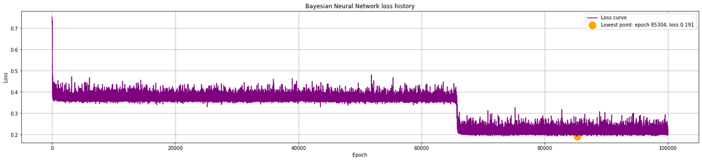

```python
plt.figure(figsize = (25, 5))
plt.plot(loss_history, c = 'purple', label = 'Loss curve')
plt.title('Bayesian Neural Network loss history')
plt.xlabel('Epoch')
plt.ylabel('Loss')
plt.grid(True, 'both')

lowest_epoch = np.argmin(loss_history)
plt.scatter(lowest_epoch, loss_history[lowest_epoch], c = 'orange', marker = 'o', label = f'Lowest point: epoch {lowest_epoch}, loss {round(loss_history[lowest_epoch], 3)}', linewidths = 10)

plt.legend()
plt.show()
```

It should be noted that, as it can be seen in the loss plot above, many more inference iterations had to be made as opposed to the first bayesian network. That is due to the problem's complexity and the simplicity of the network.

```python
# print guide params distributions
guide.requires_grad_(False)

for name, value in pyro.get_param_store().items():
    print(name, pyro.param(name), '\n')
```

```
AutoDiagonalNormal.loc Parameter containing:
tensor([-2.7605e+00, -1.7401e-01, -6.8401e-01,  4.5492e-01,  1.3919e+00,
         1.8376e-01, -2.0018e+00,  3.6459e+00,  3.2536e-03, -6.0491e-02,
         8.8580e-02, -1.4007e-01,  3.2805e+00,  2.1190e-02, -3.2676e+00,
        -1.8566e-02, -7.4185e-02,  7.3973e-02])

AutoDiagonalNormal.scale tensor([0.0669, 0.0820, 0.0156, 0.0193, 0.0392, 0.0119, 0.0337, 0.0644, 0.8923,
        0.8544, 0.0305, 0.7990, 0.3837, 0.2386, 0.4336, 0.2550, 0.1624, 0.1829])
```

```python
def sample_models(samples_no = 1000):
  return [guide(_, _) for _ in range(samples_no)]

model_samples = sample_models()
print('A model sample:\n')
for param in model_samples[0]: # print the first sample model's parameters
  print(param, '\n', str(model_samples[0][param]), '\n')
```

```
A model sample:

fc1.weight
 tensor([[-2.6910, -0.0056],
        [-0.7079,  0.4727]])

fc1.bias
 tensor([1.4016, 0.1827])

fc2.weight
 tensor([[-1.9914,  3.5985],
        [ 2.0195,  0.5256]])

fc2.bias
 tensor([0.0450, 0.0969])

out.weight
 tensor([[ 3.3027, -0.1455],
        [-3.7122, -0.2712]])

out.bias
 tensor([-0.0351,  0.1489])
```

```python
# sample 1000 models and obtain final predictions on test set
num_samples = 1000
predictive = Predictive(model, guide=guide, num_samples=num_samples)
data = predictive(test_data)
predictions = data.get('result').detach().numpy()
predictions = np.round(np.mean(predictions, axis = 0))
```

```python
# compute accuracy
correct = 0
total = 0
for i in range(len(test_data)):
    total += 1
    correct += (predictions[i] == test_labels[i]).item()
```

```python
print("Accuracy: %d %%" % (100 * correct / total))
```

```
Accuracy: 95 %
```

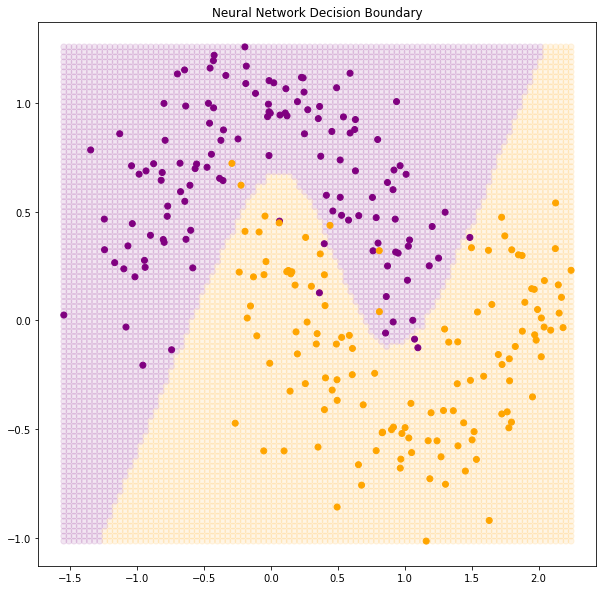

```python
plot_decision_boundary(test_data, test_labels, 'bayesian', model, guide, 1000)
```

As the results stand, the network achieved an **accuracy score of 95% on the test set**, and looking at the decision boundary, it is certain that the network successfully inferred good parameters. The points that were missed by the network are somewhat outliers, as they are found in the region of the opposing class. That is not a bad thing; if the network would have tried to correctly include those points, it would have overfit on the data.

## The Classic Neural Network

A classic neural network of the same architecture as the bayesian network was also trained:

```python
class NN(nn.Module):

    # initialize network's layers
    # this network also contains two hidden layers
    def __init__(self, input_size, hidden_size1, hidden_size2, output_size):
        super(NN, self).__init__()
        self.fc1 = nn.Linear(input_size, hidden_size1)
        self.fc2 = nn.Linear(hidden_size1, hidden_size2)
        self.out = nn.Linear(hidden_size2, output_size)

    # define how input is passed through the network
    def forward(self, x):
        x = torch.tanh(self.fc1(x))
        x = torch.tanh(self.fc2(x))
        x = self.out(x)
        return x
```

```python
net = NN(2, 2, 2, 2) # create a model of the same architecture as the bayesian network
```

```python
# adam optimizer
optimizer = torch.optim.Adam(net.parameters(), lr=0.01)

# cross entropy loss, good for classification tasks (applies logsoftmax + nll loss)
# a final layer in the network with probabilities is no longer required (this loss does that automatically)
lossf = nn.CrossEntropyLoss()

epoch_no = 2000
loss_history = []

for e in range(epoch_no):
    optimizer.zero_grad() # clear gradient buffers
    output = net(train_data)
    loss = lossf(output, train_labels) # compute loss
    if (e + 1) % 100 == 0: # print progress every few epochs
      print("Epoch", str(e + 1).ljust(5), "Loss", loss.item())
    loss_history.append(loss)
    loss.backward() # backpropagate the loss
    optimizer.step() # modify parameters accordingly
```

```
Epoch 100   Loss 0.323184072971344
Epoch 200   Loss 0.31700336933135986
Epoch 300   Loss 0.3127679228782654
Epoch 400   Loss 0.3089890778064728
Epoch 500   Loss 0.3065195381641388
Epoch 600   Loss 0.3053537905216217
Epoch 700   Loss 0.2951144874095917
Epoch 800   Loss 0.14502795040607452
Epoch 900   Loss 0.12655533850193024
Epoch 1000  Loss 0.12360094487667084
Epoch 1100  Loss 0.12140380591154099
Epoch 1200  Loss 0.11990106850862503
Epoch 1300  Loss 0.1188788041472435
Epoch 1400  Loss 0.11815529316663742
Epoch 1500  Loss 0.11761216074228287
Epoch 1600  Loss 0.11756234616041183
Epoch 1700  Loss 0.11678536981344223
Epoch 1800  Loss 0.11649563908576965
Epoch 1900  Loss 0.11624614149332047
Epoch 2000  Loss 0.11603796482086182
```

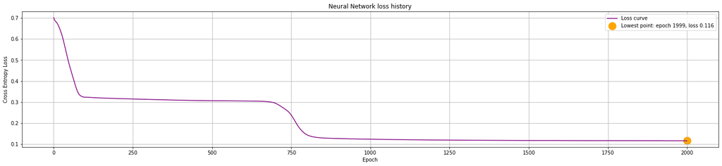

```python
plt.figure(figsize = (25, 5))
plt.plot(loss_history, c = 'purple', label = 'Loss curve')
plt.title('Neural Network loss history')
plt.xlabel('Epoch')
plt.ylabel('Cross Entropy Loss')
plt.grid(True, 'both')
lowest_epoch = np.argmin(loss_history)
plt.scatter(lowest_epoch, loss_history[lowest_epoch].detach().numpy(),
            c = 'orange', marker = 'o', label = f'Lowest point: epoch {lowest_epoch}, loss {round(loss_history[lowest_epoch].item(), 3)}', linewidths = 10)
plt.legend()
plt.show()
```

*Note: the loss history plot shows a great step around epoch 750 (similar loss curve to the bayesian network).*

```python
# print network's final parameters

for param in net.parameters():
  print(str(param), '\n')
```

```
Parameter containing:
tensor([[ 1.6116,  0.0881],
        [-0.7276,  0.2601]], requires_grad=True)

Parameter containing:
tensor([-0.8096,  0.4806], requires_grad=True)

Parameter containing:
tensor([[ 0.1737,  5.8285],
        [-3.1303, -4.4225]], requires_grad=True)

Parameter containing:
tensor([-3.6227,  0.6296], requires_grad=True)

Parameter containing:
tensor([[ 2.5061, -3.8710],
        [-1.5682,  4.7448]], requires_grad=True)

Parameter containing:
tensor([ 1.2521, -0.8314], requires_grad=True)
```

```python
# put the test set through the trained network
with torch.no_grad(): # no gradients needed to be computed for the test phase
  test_output = net(test_data)
```

```python
# output represents probabilities for each class
# argmax returns the class index with the highest probability
predictions = np.argmax(test_output, axis = 1)
```

```python
# compute accuracy
correct = 0
total = 0
for i in range(len(test_data)):
    total += 1
    correct += (predictions[i] == test_labels[i]).item()
```

```python
print("Accuracy: %d %%" % (100 * correct / total))
```

```
Accuracy: 96 %
```

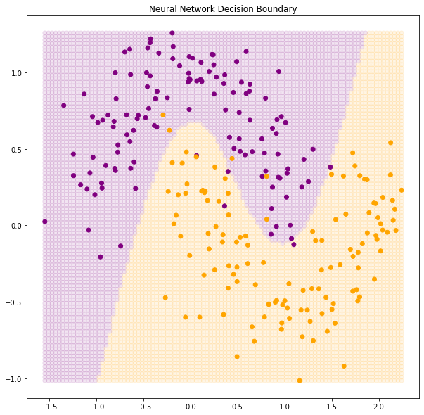

```python
plot_decision_boundary(test_data, test_labels, 'classic', net)
```

The classic network achieved an **accuracy score of 96% on the test data**, similar to the bayesian network. An interesting observation about this case would also be that the loss curve for these two networks has the similar 'staircase/step' look.

# Multinomial Classification

A last classification problem to apply a bayesian network and a classic network on is a multiclass one. Namely, four different clusters will be generated using a method from the `sklearn.dataset` package. The generated data can be seen below:

## Generate data

```python
# generate data
data, labels = make_classification(1000, n_features = 2, n_informative = 2, n_redundant = 0, n_classes = 4, n_clusters_per_class = 1, random_state = 5)
# first three quarters of the dataset for training
train_data = data[:750]
train_labels = labels[:750]
# a quarter of the data is reserved for testing
test_data = data[-250:]
test_labels = labels[-250:]
# data was shuffled upon creation to maintain train-test set distribution
```

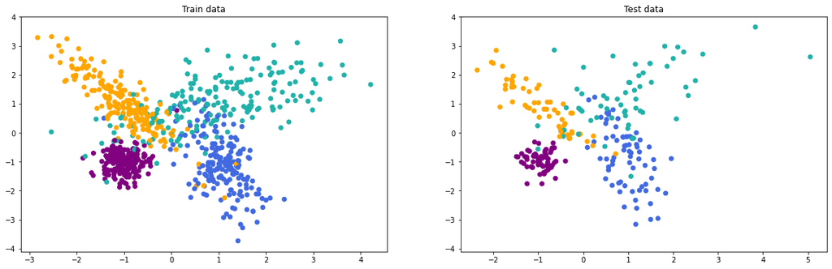

```python
label_colors = np.array(['purple', 'orange', 'royalblue', 'lightseagreen'])
label_markers = np.array(['o', 'o', 'o', 'o'])

fig, ax = plt.subplots(1, 2, figsize = (20, 6), sharey = True)
ax[0].set_title('Train data')
ax[0] = multiple_marker_style_scatter(train_data[:, 0], train_data[:, 1], label_markers[train_labels], ax = ax[0], color = label_colors[train_labels])
ax[1].set_title('Test data')
ax[1].yaxis.set_tick_params(which = 'both', labelleft = True)
ax[1] = multiple_marker_style_scatter(test_data[:, 0], test_data[:, 1], label_markers[test_labels], ax = ax[1], color = label_colors[test_labels])
plt.show()
```

```python
# create tensors from numpy arrays containing the data

train_data = torch.from_numpy(np.asarray(train_data)).type(torch.float32)
train_labels = torch.from_numpy(np.asarray(train_labels, dtype = 'int'))

test_data = torch.from_numpy(np.asarray(test_data)).type(torch.float32)
test_labels = torch.from_numpy(np.asarray(test_labels, dtype = 'int'))
```

## The Bayesian Neural Network

Surprisingly, I achieved somewhat good results on this dataset using only one hidden layer in both these networks. Again, the code is very similar to the one for the first two problems.

```python
class BNN(PyroModule):

    # initialize the network's layers
    def __init__(self, input_size, hidden_size, output_size):
        super().__init__()
        self.fc1 = PyroModule[nn.Linear](input_size, hidden_size)
        self.fc1.weight = PyroSample(dist.Normal(0., 1.).expand([hidden_size, input_size]).to_event(2))
        self.fc1.bias = PyroSample(dist.Normal(0., 1.).expand([hidden_size]))

        self.out = PyroModule[nn.Linear](hidden_size, output_size)
        self.out.weight = PyroSample(dist.Normal(0., 1.).expand([output_size, hidden_size]).to_event(2))
        self.out.bias = PyroSample(dist.Normal(0., 1.).expand([output_size]))

    # define how input is passed through the network
    # if provided, y is the observed variable
    def forward(self, x, y = None):
        x = torch.tanh(self.fc1(x))
        x = self.out(x)
        p = torch.softmax(x, dim = 1)

        with pyro.plate("data", x.shape[0]):
            result = pyro.sample("result", dist.Categorical(p), obs = y)

        return result
```

```python
model = BNN(2, 4, 4) # create the model
guide = AutoDiagonalNormal(model) # automatically create the guide for the model
optim = Adam({"lr": 0.01}) # adam optimizer

svi = SVI(model, guide, optim, loss = Trace_ELBO()) # inference
```

```python
pyro.clear_param_store()

num_iterations = 30000
loss_history = []

for it in range(num_iterations):
  loss = svi.step(train_data, train_labels) # pass training data and labels (observed variable)
  total_epoch_loss_train = loss / len(train_data) # average loss per train entry
  if (it + 1) % 1000 == 0: # print progress after some time
    print("Iteration ", str(it + 1).ljust(5), " Loss ", total_epoch_loss_train)
  loss_history.append(total_epoch_loss_train)
```

```
Iteration  1000   Loss  0.4482775872548421
Iteration  2000   Loss  0.4393960615793864
Iteration  3000   Loss  0.43037289174397786
Iteration  4000   Loss  0.42791225051879883
Iteration  5000   Loss  0.4306589323679606
Iteration  6000   Loss  0.4350481039683024
Iteration  7000   Loss  0.43499143664042156
Iteration  8000   Loss  0.44830184849103294
Iteration  9000   Loss  0.4249531059265137
Iteration  10000  Loss  0.45749170112609866
Iteration  11000  Loss  0.44210901387532553
Iteration  12000  Loss  0.4555128568013509
Iteration  13000  Loss  0.42838322257995604
Iteration  14000  Loss  0.4284599075317383
Iteration  15000  Loss  0.4340694122314453
Iteration  16000  Loss  0.42609033902486165
Iteration  17000  Loss  0.4511449089050293
Iteration  18000  Loss  0.433464604695638
Iteration  19000  Loss  0.41744893900553387
Iteration  20000  Loss  0.4161365935007731
Iteration  21000  Loss  0.43848122787475585
Iteration  22000  Loss  0.43012676493326824
Iteration  23000  Loss  0.43368242390950523
Iteration  24000  Loss  0.44043959871927896
Iteration  25000  Loss  0.4449976304372152
Iteration  26000  Loss  0.4269517065684001
Iteration  27000  Loss  0.4315290075937907
Iteration  28000  Loss  0.4376855703989665
Iteration  29000  Loss  0.42515927950541177
Iteration  30000  Loss  0.4535604305267334
```

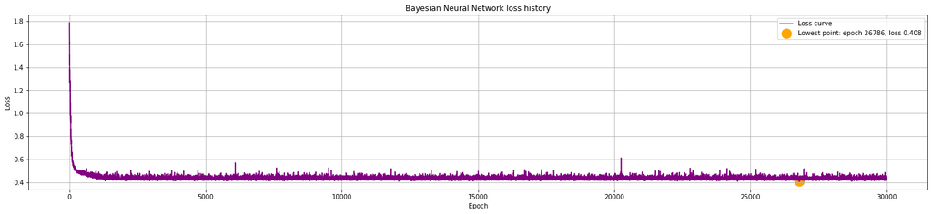

```python
plt.figure(figsize = (25, 5))
plt.plot(loss_history, c = 'purple', label = 'Loss curve')
plt.title('Bayesian Neural Network loss history')
plt.xlabel('Epoch')
plt.ylabel('Loss')
plt.grid(True, 'both')

lowest_epoch = np.argmin(loss_history)
plt.scatter(lowest_epoch, loss_history[lowest_epoch], c = 'orange', marker = 'o', label = f'Lowest point: epoch {lowest_epoch}, loss {round(loss_history[lowest_epoch], 3)}', linewidths = 10)

plt.legend()
plt.show()
```

```python
guide.requires_grad_(False)

for name, value in pyro.get_param_store().items():
    print(name, pyro.param(name), '\n')
```

```
AutoDiagonalNormal.loc Parameter containing:
tensor([-2.0603, -1.2334,  2.3609,  0.0374, -0.2599, -2.4986, -0.2759, -1.5208,
         0.9741,  0.3027, -1.0387,  1.2950, -0.6248, -2.5749,  2.4103, -0.1615,
         3.0949,  0.2457, -1.6963, -1.7413, -1.4096,  2.2891,  0.3980,  2.1583,
        -1.0764,  0.0421, -1.1010, -0.2562, -0.4742, -0.4021, -0.6647,  1.5350])

AutoDiagonalNormal.scale tensor([0.1801, 0.1025, 0.3153, 0.1646, 0.1198, 0.2279, 0.1084, 0.1486, 0.0993,
        0.1410, 0.1037, 0.1047, 0.2634, 0.2314, 0.2928, 0.2426, 0.1617, 0.2047,
        0.1956, 0.1998, 0.2449, 0.1776, 0.2132, 0.1935, 0.1801, 0.1577, 0.1615,
        0.1650, 0.2330, 0.1595, 0.1767, 0.1262])
```

```python
def sample_models(samples_no = 1):
  return [guide(_, _) for _ in range(samples_no)]

model_samples = sample_models()
print('A model sample:\n')
for param in model_samples[0]:
  print(param, '\n', str(model_samples[0][param]), '\n')
```

```
A model sample:

fc1.weight
 tensor([[-2.1251, -1.2871],
        [ 2.2687,  0.0806],
        [-0.3616, -2.4797],
        [-0.3198, -1.7600]])

fc1.bias
 tensor([ 1.0278,  0.5163, -1.0387,  1.2632])

out.weight
 tensor([[-0.6452, -2.4494,  2.8073, -0.3662],
        [ 3.0326,  0.0953, -1.6468, -1.8580],
        [-1.4735,  2.3771,  0.5493,  1.9537],
        [-0.8505, -0.0449, -1.1215,  0.1357]])

out.bias
 tensor([-0.0437, -0.3037, -0.7051,  1.3750])
```

```python
# sampling 1000 models and obtain final predictions on the test set
num_samples = 1000
predictive = Predictive(model, guide=guide, num_samples=num_samples)
data = predictive(test_data)
predictions = data.get('result').detach().numpy()
predictions = np.round(np.mean(predictions, axis = 0))
```

```python
# compute accuracy
correct = 0
total = 0
for i in range(len(test_data)):
    total += 1
    correct += (predictions[i] == test_labels[i]).item()
```

```python
print("Accuracy: %d %%" % (100 * correct / total))
```

```
Accuracy: 80 %
```

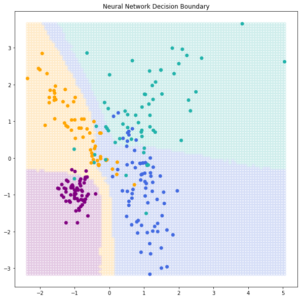

```python
plot_decision_boundary(test_data, test_labels, 'bayesian', model, guide, 1000)
```

It can be seen that the accuracy is not as great as in the case of the first two problems. This bayesian network obtained an **accuracy score of 80% on the test set**. It can also be seen that the separation of the regions is not that great (see the case of the orange and blue colored classes above).

## The Classic Neural Network

```python
class NN(nn.Module):

    # initialize network's layers
    def __init__(self, input_size, hidden_size, output_size):
        super(NN, self).__init__()
        self.fc1 = nn.Linear(input_size, hidden_size)
        self.out = nn.Linear(hidden_size, output_size)

    # define how input is passed through the network
    def forward(self, x):
        x = torch.tanh(self.fc1(x))
        x = self.out(x)
        return x
```

```python
net = NN(2, 4, 4) # create the model
```

```python
# adam optimizer
optimizer = torch.optim.Adam(net.parameters(), lr=0.01)

# cross entropy loss, good for classification (logsoftmax + nll loss)
lossf = nn.CrossEntropyLoss()

epoch_no = 2000
loss_history = []

for e in range(epoch_no):
    optimizer.zero_grad() # clear gradient buffers
    output = net(train_data)
    loss = lossf(output, train_labels) # compute loss
    if (e + 1) % 100 == 0: # print progress every few epochs
      print("Epoch", str(e + 1).ljust(5), "Loss", loss.item())
    loss_history.append(loss)
    loss.backward() # backpropagate the loss
    optimizer.step() # modify weights accordingly
```

```
Epoch 100   Loss 0.4599463641643524
Epoch 200   Loss 0.39003247022628784
Epoch 300   Loss 0.37355664372444153
Epoch 400   Loss 0.35405781865119934
Epoch 500   Loss 0.3384794294834137
Epoch 600   Loss 0.327946275472641
Epoch 700   Loss 0.321133553981781
Epoch 800   Loss 0.31689247488975525
Epoch 900   Loss 0.31406500935554504
Epoch 1000  Loss 0.31198224425315857
Epoch 1100  Loss 0.31031233072280884
Epoch 1200  Loss 0.30888456106185913
Epoch 1300  Loss 0.3076043128967285
Epoch 1400  Loss 0.3064207136631012
Epoch 1500  Loss 0.3053086996078491
Epoch 1600  Loss 0.3042583763599396
Epoch 1700  Loss 0.3032653033733368
Epoch 1800  Loss 0.3023245930671692
Epoch 1900  Loss 0.30143189430236816
Epoch 2000  Loss 0.3005813658237457
```

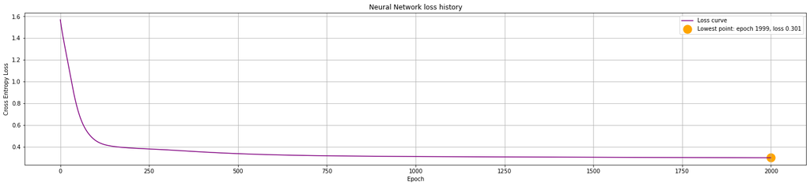

```python
plt.figure(figsize = (25, 5))
plt.plot(loss_history, c = 'purple', label = 'Loss curve')
plt.title('Neural Network loss history')
plt.xlabel('Epoch')
plt.ylabel('Cross Entropy Loss')
plt.grid(True, 'both')
lowest_epoch = np.argmin(loss_history)
plt.scatter(lowest_epoch, loss_history[lowest_epoch].detach().numpy(),
            c = 'orange', marker = 'o', label = f'Lowest point: epoch {lowest_epoch}, loss {round(loss_history[lowest_epoch].item(), 3)}', linewidths = 10)
plt.legend()
plt.show()
```

```python
# view network's final parameters
for param in net.parameters():
  print(str(param), '\n')
```

```
Parameter containing:
tensor([[-0.1395, -1.5334],
        [-2.0339, -0.0207],
        [ 1.3952,  1.2152],
        [ 0.2735,  3.4437]], requires_grad=True)

Parameter containing:
tensor([ 1.7455, -0.0136, -1.3256,  1.3734], requires_grad=True)

Parameter containing:
tensor([[ 0.5822,  4.0317,  0.6898, -2.1450],
        [-3.4082,  0.0085, -3.2412,  2.1788],
        [ 2.7296, -2.7123,  2.3388,  0.6393],
        [ 0.2423,  0.5947,  3.7765,  1.3912]], requires_grad=True)

Parameter containing:
tensor([-1.7372,  1.7295,  0.6013,  4.3970], requires_grad=True)
```

```python
with torch.no_grad(): # no gradient computations for the testing phase
  test_output = net(test_data)
```

```python
# argmax gets the class with the highest probability out of those given by the network
predictions = np.argmax(test_output, axis = 1)
```

```python
# compute accuracy
correct = 0
total = 0
for i in range(len(test_data)):
    total += 1
    correct += (predictions[i] == test_labels[i]).item()
```

```python
print("Accuracy: %d %%" % (100 * correct / total))
```

```
Accuracy: 90 %
```

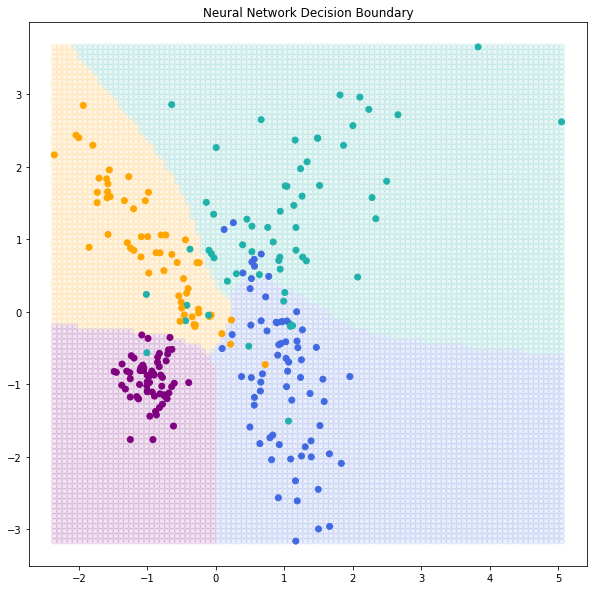

```python
plot_decision_boundary(test_data, test_labels, 'classic', net)
```

# Results summary. Bayesian - Classic Neural Networks comparison

A summary of the experiment results and comparisons can be seen below.

| Problem type | Bayesian Network results | Classic Network results | Notes |
| --- | --- | --- | --- |
| Binary classification (linearly separable) | 100% test acc. | 100% test acc. | Sanity check, same results, simple and quick inference/training |
| Binary classification (non-linearly separable) | 95% test acc. | 96% test acc. | More complex problem, same results, neccesity of more complex networks and more inference/training time |
| Multinomial classification | 80% test acc. | 90% test acc. | The classic network clearly outperformed the bayesian network |

# Extra Experiment: Inference on network architecture

I had an idea of introducing a categorical parameter in the bayesian networks with the purpose of finding a good hidden layer size. Thus, **the hidden layer size would also be inferred**.

To start with, I wanted to see if it works for the sanity check. Next, the question would be: could the bayesian network for the multinomial classification (which got 80% accuracy) be improved?

## Sanity Check (Again)

### Generate data

```python
def generate_data(samples_no):
  X = np.random.randn(samples_no, 2) # generating random 2D input values
  Y = np.tanh(X[:, 0] + X[:, 1])     # this is the value computed by a node on the hidden layer
  Y = 1 / (1 + np.exp(-(Y + Y)))     # applying sigmoid function
  Y = Y > 0.5                        # label 1 if sigmoid is greater than 0.5, else 0
  return X, Y.astype(int)            # return samples_no such points and their labels
```

```python
train_data, train_labels = generate_data(100)
test_data, test_labels = generate_data(100)
```

```python
# create tensors from the initial numpy arrays containing the data

train_data = torch.from_numpy(np.asarray(train_data)).type(torch.float32)
train_labels = torch.from_numpy(np.asarray(train_labels, dtype = 'int'))

test_data = torch.from_numpy(np.asarray(test_data)).type(torch.float32)
test_labels = torch.from_numpy(np.asarray(test_labels, dtype = 'int'))
```

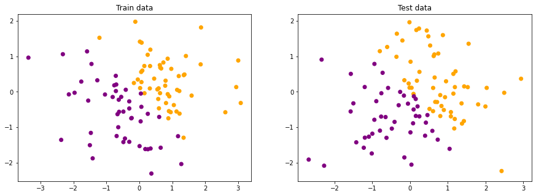

```python
label_colors = np.array(['purple', 'orange'])
label_markers = np.array(['o', 'o'])

fig, ax = plt.subplots(1, 2, figsize = (15, 5), sharey = True)
ax[0].set_title('Train data')
ax[0] = multiple_marker_style_scatter(train_data[:, 0], train_data[:, 1], label_markers[train_labels], ax =  ax[0],  color = label_colors[train_labels])
ax[1].set_title('Test data')
ax[1].yaxis.set_tick_params(which = 'both', labelleft = True)
ax[1] = multiple_marker_style_scatter(test_data[:, 0], test_data[:, 1], label_markers[test_labels], ax = ax[1], color = label_colors[test_labels])
plt.show()
```

### The Bayesian Neural Network

```python
class BNN(PyroModule):

    # define the initialization method which creates the network's layers
    def __init__(self, input_size, output_size):
        super().__init__()

        # the probabilities for each possible size (0 for size 0)
        p_hidden = torch.randn(6)
        p_hidden[0] = 0
        for i in range(1, 6): # possible hidden layer sizes: 1, 2, 3, 4, 5
          p_hidden[i] = 0.2

        # infer the size of the hidden layer
        self.hidden_size = PyroSample(dist.Categorical(p_hidden))
        hidden_size = self.hidden_size

        # the hidden fully connected layer
        self.fc1 = PyroModule[nn.Linear](input_size, hidden_size, bias = False)
        self.fc1.weight = PyroSample(dist.Normal(0., 1.).expand([hidden_size, input_size]).to_event(2))
        # the output layer
        self.out = PyroModule[nn.Linear](hidden_size, output_size, bias = False)
        self.out.weight = PyroSample(dist.Normal(0., 1.).expand([output_size, hidden_size]).to_event(2))

    # define the way of passing the input through the network
    def forward(self, x, y = None):
        x = self.fc1(x)
        x = torch.tanh(x)
        x = self.out(x)
        p1 = torch.sigmoid(x) # a value between 0 and 1 for each input entry
        # p1 is the probability of the input to produce a label of value 1

        # also deduce the probability of the input to produce a label of value 0
        # thus, p will be given to a Categorical distribution for the label
        p = torch.randn(x.shape[0], 2)
        for i in range(len(p1)):
            p[i][0] = 1 - p1[i]
            p[i][1] = p1[i]

        # using plate because data is given in batchez, not individual entries
        with pyro.plate("data", x.shape[0]):
            result = pyro.sample("result", dist.Categorical(p), obs = y) # note the obs is given for inference
            # the resulting labels are given by a Categorical distribution
            # for training, the labels will be given to this method and they will be marked as observed variable
        return result
```

```python
# create the bayesian network with the same architecture that was used to generate data
model = BNN(2, 1)
# automatically create a guide for inference
guide = AutoDiagonalNormal(model)
# an Adam optimizer will be used
optim = Adam({"lr": 0.01})

# Stochastic Variational Inference in Pyro
svi = SVI(model, guide, optim, loss = Trace_ELBO())
# I chose the most commonly used loss, which is Trace_ELBO()
```

```python
pyro.clear_param_store()

num_iterations = 1000
loss_history = [] # this will be used for plotting

for it in range(num_iterations):
  loss = svi.step(train_data, train_labels) # compute the loss on the training data
                                            # the labels are also passed because they are the observed variable
  total_epoch_loss_train = loss / len(train_data) # average entry loss
  if (it + 1) % 100 == 0: # print progress every few iterations
    print("Iteration ", str(it + 1).ljust(5), " Loss ", total_epoch_loss_train)
  loss_history.append(total_epoch_loss_train)
```

```
Iteration  100    Loss  0.3983267867565155
Iteration  200    Loss  0.24967498421669007
Iteration  300    Loss  0.26335429191589355
Iteration  400    Loss  0.21924368619918824
Iteration  500    Loss  0.21183831334114075
Iteration  600    Loss  0.2662214660644531
Iteration  700    Loss  0.1910245895385742
Iteration  800    Loss  0.24455942153930665
Iteration  900    Loss  0.2140561509132385
Iteration  1000   Loss  0.20387938022613525
```

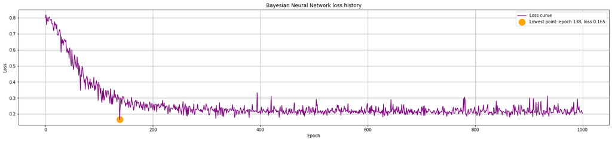

```python
plt.figure(figsize = (25, 5))
plt.plot(loss_history, c = 'purple', label = 'Loss curve')
plt.title('Bayesian Neural Network loss history')
plt.xlabel('Epoch')
plt.ylabel('Loss')
plt.grid(True, 'both')

lowest_epoch = np.argmin(loss_history)
plt.scatter(lowest_epoch, loss_history[lowest_epoch], c = 'orange', marker = 'o', label = f'Lowest point: epoch {lowest_epoch}, loss {round(loss_history[lowest_epoch], 3)}', linewidths = 10)

plt.legend()
plt.show()
```

```python
guide.requires_grad_(False)

for name, value in pyro.get_param_store().items():
    print(name, pyro.param(name), '\n')
```

```
AutoDiagonalNormal.loc Parameter containing:
tensor([ 1.5093,  1.4173, -1.4661, -1.3889,  2.2565, -2.2364])

AutoDiagonalNormal.scale tensor([0.3146, 0.3357, 0.2978, 0.3269, 0.6195, 0.5904])
```

```python
def sample_models(samples_no = 1000):
  return [guide(_, _) for _ in range(samples_no)]

model_samples = sample_models()
print('A model sample:\n')
for param in model_samples[0]:
  print(param, '\n', str(model_samples[0][param]), '\n')
```

```
A model sample:

fc1.weight
 tensor([[ 1.5427,  1.2051],
        [-1.7372, -1.5791]])

out.weight
 tensor([[ 1.5936, -2.2280]])
```

Looking at the sample model's parameters, we can deduce that the chosen hidden layer size was 2 out of 1 to 5 possible sizes.

```python
# sampling 1000 models and averaging their results to obtain final predictions on the test set
num_samples = 1000
predictive = Predictive(model, guide=guide, num_samples=num_samples)
data = predictive(test_data)
predictions = data.get('result').detach().numpy()
predictions = np.round(np.mean(predictions, axis = 0))
```

```python
# compute the accuracy
correct = 0
total = 0
for i in range(len(test_data)):
    total += 1
    correct += (predictions[i] == test_labels[i]).item()
```

```python
print("Accuracy: %d %%" % (100 * correct / total))
```

```
Accuracy: 100 %
```

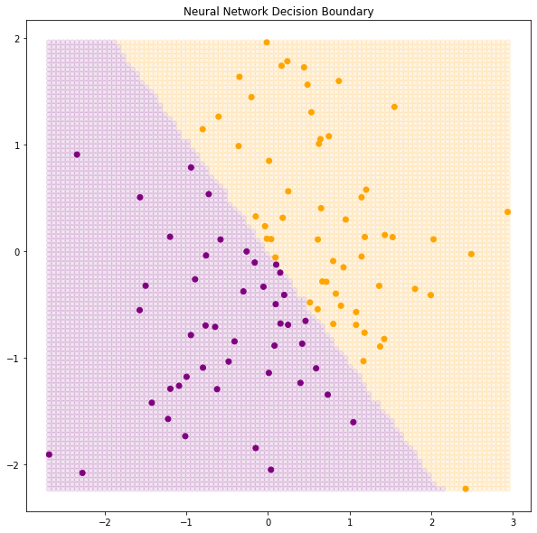

```python
plot_decision_boundary(test_data, test_labels, 'bayesian', model, guide, 1000)
```

It can be seen that the bayesian network whose hidden layer size was also inferred succesfully completed the task, achieving **100% accuracy on the test set**.

## Multinomial Classification (Second Attempt)

Because the sanity check was a success in the case of the inferred hidden layer size, we can proceed to the multiclass problem. The initial bayesian network had a hidden layer of size 4.

### Generate data

```python
data, labels = make_classification(1000, n_features = 2, n_informative = 2, n_redundant = 0, n_classes = 4, n_clusters_per_class = 1, random_state = 5)
train_data = data[:750]
train_labels = labels[:750]
test_data = data[-250:]
test_labels = labels[-250:]
```

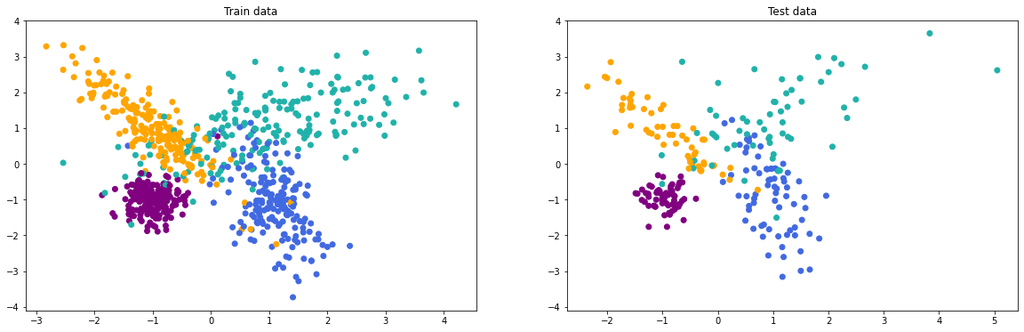

```python
label_colors = np.array(['purple', 'orange', 'royalblue', 'lightseagreen'])
label_markers = np.array(['o', 'o', 'o', 'o'])

fig, ax = plt.subplots(1, 2, figsize = (20, 6), sharey = True)
ax[0].set_title('Train data')
ax[0] = multiple_marker_style_scatter(train_data[:, 0], train_data[:, 1], label_markers[train_labels], ax = ax[0], color = label_colors[train_labels])
ax[1].set_title('Test data')
ax[1].yaxis.set_tick_params(which = 'both', labelleft = True)
ax[1] = multiple_marker_style_scatter(test_data[:, 0], test_data[:, 1], label_markers[test_labels], ax = ax[1], color = label_colors[test_labels])
plt.show()
```

```python
train_data = torch.from_numpy(np.asarray(train_data)).type(torch.float32)
train_labels = torch.from_numpy(np.asarray(train_labels, dtype = 'int'))

test_data = torch.from_numpy(np.asarray(test_data)).type(torch.float32)
test_labels = torch.from_numpy(np.asarray(test_labels, dtype = 'int'))
```

### The Bayesian Neural Network

```python
class BNN(PyroModule):

    # initialize the network's layers
    def __init__(self, input_size, output_size):
        super().__init__()

        # the probabilities for each possible hidden layer size
        p_hidden = torch.randn(9)
        p_hidden[0] = 0
        for i in range(1, 9): # possible sizes: 1, 2, 3, ..., 8
          p_hidden[i] = 0.125

        # infer the size of the hidden layer
        self.hidden_size = PyroSample(dist.Categorical(p_hidden))
        # self.hidden_size = pyro.sample('hidden_size', dist.Categorical(p_hidden))
        hidden_size = self.hidden_size.type(torch.int32).item()


        self.fc1 = PyroModule[nn.Linear](input_size, hidden_size)
        self.fc1.weight = PyroSample(dist.Normal(0., 1.).expand([hidden_size, input_size]).to_event(2))
        self.fc1.bias = PyroSample(dist.Normal(0., 1.).expand([hidden_size]))

        self.out = PyroModule[nn.Linear](hidden_size, output_size)
        self.out.weight = PyroSample(dist.Normal(0., 1.).expand([output_size, hidden_size]).to_event(2))
        self.out.bias = PyroSample(dist.Normal(0., 1.).expand([output_size]))


    # define how input is passed through the network
    # if provided, y is the observed variable
    def forward(self, x, y = None):
        x = torch.tanh(self.fc1(x))
        x = self.out(x)
        p = torch.softmax(x, dim = 1)

        with pyro.plate("data", x.shape[0]):
            result = pyro.sample("result", dist.Categorical(p), obs = y)

        return result
```

```python
model = BNN(2, 4)
guide = AutoDiagonalNormal(model)
optim = Adam({"lr": 0.01})

svi = SVI(model, guide, optim, loss = Trace_ELBO())
```

```python
pyro.clear_param_store()

num_iterations = 200
loss_history = []

for it in range(num_iterations):
  loss = svi.step(train_data, train_labels)
  total_epoch_loss_train = loss / len(train_data)
  if (it + 1) % 25 == 0:
    print("Iteration ", str(it + 1).ljust(5), " Loss ", total_epoch_loss_train)
  loss_history.append(total_epoch_loss_train)
```

```
Iteration  25     Loss  1.186389773050944
Iteration  50     Loss  0.9043064982096354
Iteration  75     Loss  0.7217393830617269
Iteration  100    Loss  0.591231302579244
Iteration  125    Loss  0.5574119367599487
Iteration  150    Loss  0.5328769785563151
Iteration  175    Loss  0.5336794214248657
Iteration  200    Loss  0.520362419128418
```

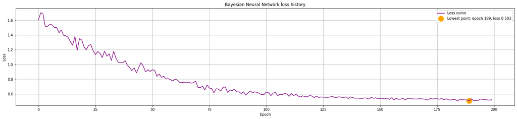

```python
plt.figure(figsize = (25, 5))
plt.plot(loss_history, c = 'purple', label = 'Loss curve')
plt.title('Bayesian Neural Network loss history')
plt.xlabel('Epoch')
plt.ylabel('Loss')
plt.grid(True, 'both')

lowest_epoch = np.argmin(loss_history)
plt.scatter(lowest_epoch, loss_history[lowest_epoch], c = 'orange', marker = 'o', label = f'Lowest point: epoch {lowest_epoch}, loss {round(loss_history[lowest_epoch], 3)}', linewidths = 10)

plt.legend()
plt.show()
```

```python
guide.requires_grad_(False)

for name, value in pyro.get_param_store().items():
    print(name, pyro.param(name), '\n')
```

```
AutoDiagonalNormal.loc Parameter containing:
tensor([ 1.2409,  0.2031,  0.0554,  1.0755, -1.2867, -0.2411,  0.5601, -0.9848,
         0.2534, -1.0789,  0.0843,  0.3828, -0.3041,  0.5791, -0.2556, -1.5947,
        -1.0121,  1.0091,  0.9492,  0.5118, -1.1264,  0.4794,  0.4239, -0.6303,
        -1.0203,  0.9016, -0.4300, -1.1174,  0.8994,  1.2541,  0.9616,  0.3818,
        -0.2262,  0.1555, -1.2371, -0.1430,  0.3916, -0.0574,  0.5341])

AutoDiagonalNormal.scale tensor([0.1074, 0.0885, 0.1079, 0.1254, 0.1458, 0.1171, 0.1163, 0.1203, 0.0723,
        0.0967, 0.0927, 0.1223, 0.1236, 0.1325, 0.0826, 0.1269, 0.1270, 0.1500,
        0.1713, 0.1344, 0.1323, 0.1746, 0.1478, 0.1257, 0.1389, 0.1189, 0.1742,
        0.1418, 0.1332, 0.1533, 0.1345, 0.1324, 0.1394, 0.1737, 0.1284, 0.1284,
        0.1058, 0.1190, 0.1129])
```

```python
def sample_models(samples_no = 1000):
  return [guide(_, _) for _ in range(samples_no)]

model_samples = sample_models()
print('A model sample:\n')
for param in model_samples[0]:
  print(param, '\n', str(model_samples[0][param]), '\n')
```

```
A model sample:

fc1.weight
 tensor([[ 1.2171,  0.2220],
        [ 0.0446,  0.9501],
        [-1.5610, -0.1978],
        [ 0.6263, -0.7672],
        [ 0.1810, -0.9488]])

fc1.bias
 tensor([ 0.1748,  0.4926, -0.3197,  0.5475, -0.1597])

out.weight
 tensor([[-1.7175, -1.1795,  0.9664,  0.9896,  0.5378],
        [-1.3288,  0.5983,  0.5640, -0.7033, -0.9391],
        [ 0.7796, -0.4210, -1.1977,  1.0385,  1.2021],
        [ 0.7461,  0.3681, -0.0456, -0.1829, -1.3989]])

out.bias
 tensor([-0.1536,  0.2989, -0.1462,  0.7024])
```

Looking at the sample mode's parameters, we can deduce that the inferred hidden layer size is 5 , which is different from the initial Bayesian network I tried (with hidden layer of size 4).

```python
num_samples = 1000
predictive = Predictive(model, guide=guide, num_samples=num_samples)
data = predictive(test_data)
predictions = data.get('result').detach().numpy()
predictions = np.round(np.mean(predictions, axis = 0))
```

```python
correct = 0
total = 0
for i in range(len(test_data)):
    total += 1
    correct += (predictions[i] == test_labels[i]).item()
```

```python
print("Accuracy: %d %%" % (100 * correct / total))
```

```
Accuracy: 81 %
```

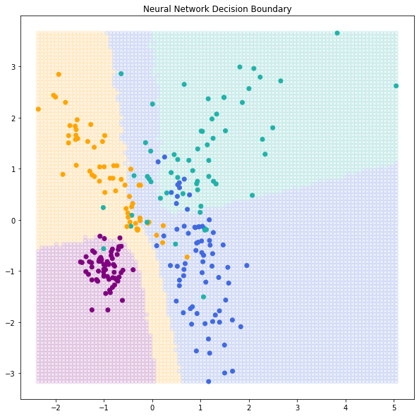

```python
plot_decision_boundary(test_data, test_labels, 'bayesian', model, guide, 1000)
```

As a conclusion, the different hidden layer size did not produce such a great change (only 1% improvement), which is to be expected for this problem. The decision boundary is also very similar to the bayesian network I tried initially.

## Conclusion of the experiment

It was interesting to see what hidden layer size was chosen for the network. Unfortunately, in the case of only one hidden layer, the difference is really not significant.

However, it is good to know that the experiment is not meaningless. In the case of more complex networks, with many hidden layers and a greater number of neurons per layer, the change may be much more meaningful.